# Explainable Sentiment Analysis using Automatically Generated Counterfactuals and Shapley Values

```python
import pandas as pd
import numpy as np
from sklearn.pipeline import Pipeline
from sklearn.feature_extraction.text import TfidfVectorizer
from sklearn.svm import SVC, LinearSVC
from sklearn.metrics import classification_report
from sklearn.model_selection import train_test_split
# from tqdm import tqdm
```

```python
import spacy
nlp = spacy.load("en_core_web_sm")
```

### Text Preprocessing for SVM Classifier

```python
def preprocess(text):
    """Preprocess the given text by tokenising it, removing any stop words,
    replacing each remaining token with its lemma (base form), and discarding
    all lemmas that contain non-alphabetical characters.

    Arguments:
      text (str): The text to preprocess.

    Returns:
      The list of remaining lemmas after preprocessing (represented as strings).
    """
    lemma = []
    # text.split(' ')
    doc = nlp(text)
    # print(text)
    for token in doc:
      if token.is_alpha == True and token.is_stop == False:
        # print(token)
        lemma.append(token.lemma_.lower())
        # print(lemma)
    return lemma
```

### Importing all the necessary Data

- auto_cf is Automatically Generated Counterfactuals from yang et.al
- human_cf_train, human_cf_test are human generated counterfactuals combined with original IMDB movie reviews from Kaushik et.al
- cf_train and cf_test are human generated counterfactuals only from Kaushik et.al
- original_train_df, original_test_df are original IMDB movie reviews from Kaushik et.al
- combined_train_df, combined_test_df are the Augmented datasets which is original data combined with automatically generated counterfactuals

```python
# Automatically Generated CFs
auto_df = pd.read_csv('bert-base_512_selected.csv')
auto_cf = auto_df.drop(labels='original', axis=1)
auto_cf['label'] = auto_cf['label'].apply(lambda x: 1 if x == 0 else 0)

# Human Generated CFs Kaushik et.al (Train and Test) Combined
human_cf_train = pd.read_csv('https://raw.githubusercontent.com/acmi-lab/counterfactually-augmented-data/master/sentiment/combined/train.tsv', delimiter='\t')
human_cf_test = pd.read_csv('https://raw.githubusercontent.com/acmi-lab/counterfactually-augmented-data/master/sentiment/combined/test.tsv', delimiter='\t')
human_cf_train = human_cf_train.map(lambda s: s.lower() if type(s) == str else s)
human_cf_test = human_cf_test.map(lambda s: s.lower() if type(s) == str else s)

human_cf_train['Sentiment'] = human_cf_train['Sentiment'].replace('negative', 0)
human_cf_train['Sentiment'] = human_cf_train['Sentiment'].replace('positive', 1)

human_cf_test['Sentiment'] = human_cf_test['Sentiment'].replace('negative', 0)
human_cf_test['Sentiment'] = human_cf_test['Sentiment'].replace('positive', 1)

#Human Generated CFs Kaushik et.al
cf_train = pd.read_csv('https://raw.githubusercontent.com/acmi-lab/counterfactually-augmented-data/master/sentiment/new/train.tsv', delimiter='\t')
cf_test = pd.read_csv('https://raw.githubusercontent.com/acmi-lab/counterfactually-augmented-data/master/sentiment/new/test.tsv', delimiter='\t')
cf_train = cf_train.map(lambda s: s.lower() if type(s) == str else s)
cf_test = cf_test.map(lambda s: s.lower() if type(s) == str else s)

cf_train['Sentiment'] = cf_train['Sentiment'].replace('negative', 0)
cf_train['Sentiment'] = cf_train['Sentiment'].replace('positive', 1)

cf_test['Sentiment'] = cf_test['Sentiment'].replace('negative', 0)
cf_test['Sentiment'] = cf_test['Sentiment'].replace('positive', 1)

# Original IMDB Reviews (Train and Test) from Kaushik et.al
original_train_df = pd.read_csv('https://raw.githubusercontent.com/acmi-lab/counterfactually-augmented-data/master/sentiment/orig/train.tsv',delimiter='\t')
original_train_df = original_train_df.map(lambda s: s.lower() if type(s) == str else s)
original_train_df['Sentiment'] = original_train_df['Sentiment'].replace('negative', 0)
original_train_df['Sentiment'] = original_train_df['Sentiment'].replace('positive', 1)

original_test_df = pd.read_csv('https://raw.githubusercontent.com/acmi-lab/counterfactually-augmented-data/master/sentiment/orig/test.tsv',delimiter='\t')
original_test_df = original_test_df.map(lambda s: s.lower() if type(s) == str else s)
original_test_df['Sentiment'] = original_test_df['Sentiment'].replace('negative', 0)
original_test_df['Sentiment'] = original_test_df['Sentiment'].replace('positive', 1)

# Combining Original Train and Automatically generated CFs to create augmented dataset.
combine_orig_cf_x = pd.DataFrame()
combine_orig_cf_y = pd.DataFrame()

combine_orig_cf_x['combined_reviews'] = pd.concat([original_train_df['Text'],auto_cf['counterfact']],ignore_index=True)
combine_orig_cf_x = combine_orig_cf_x.map(lambda s: s.lower() if type(s) == str else s)
# orig_cf_y['combined_labels'] = pd.concat([train_y['labels'],aug_df['label']],ignore_index=True)
combine_orig_cf_y['combined_labels'] = pd.concat([original_train_df['Sentiment'],auto_cf['label']],ignore_index=True)

combined_df = pd.concat([combine_orig_cf_x['combined_reviews'],combine_orig_cf_y['combined_labels']], axis=1)
combined_train_df, combined_test_df = train_test_split(combined_df, test_size=0.15, random_state=42)
```

### Training and Testing an SVM classifier on different combinations of Data

```python
# Train on original data and test on original data.
pipe = Pipeline(steps=[('vectorizer', TfidfVectorizer(tokenizer=preprocess)), ('SVC', SVC(kernel='linear', probability=True))])
ypred = pipe.fit(original_train_df['Text'], original_train_df['Sentiment']).predict(original_test_df['Text'])

# Train on challenge data data and test on combined challenge data
pipe2 = Pipeline(steps=[('vectorizer', TfidfVectorizer(tokenizer=preprocess)), ('SVC', SVC(kernel='linear', probability=True))])
ypred2 = pipe2.fit(human_cf_train['Text'], human_cf_train['Sentiment']).predict(human_cf_test['Text'])

# Train on augmented data and test on augmented data
pipe3 = Pipeline(steps=[('vectorizer', TfidfVectorizer(tokenizer=preprocess)), ('SVC', SVC(kernel='linear', probability=True))])
ypred3 = pipe3.fit(combined_train_df['combined_reviews'], combined_train_df['combined_labels']).predict(combined_test_df['combined_reviews'])

# Train on original data and test on combined challenge data
pipe4 = Pipeline(steps=[('vectorizer', TfidfVectorizer(tokenizer=preprocess)), ('SVC', SVC(kernel='linear', probability=True))])
ypred4 = pipe4.fit(original_train_df['Text'], original_train_df['Sentiment']).predict(human_cf_test['Text'])

#Train on original data and test on augmented data
pipe5 = Pipeline(steps=[('vectorizer', TfidfVectorizer(tokenizer=preprocess)), ('SVC', SVC(kernel='linear', probability=True))])
ypred5 = pipe5.fit(original_train_df['Text'], original_train_df['Sentiment']).predict(combined_test_df['combined_reviews'])

# Train on challenge data and test on original data
pipe6 = Pipeline(steps=[('vectorizer', TfidfVectorizer(tokenizer=preprocess)), ('SVC', SVC(kernel='linear', probability=True))])
ypred6 = pipe6.fit(human_cf_train['Text'], human_cf_train['Sentiment']).predict(original_test_df['Text'])

# Train on augmented data and test on original data
pipe7 = Pipeline(steps=[('vectorizer', TfidfVectorizer(tokenizer=preprocess)), ('SVC', SVC(kernel='linear', probability=True))])
ypred7 = pipe7.fit(combined_train_df['combined_reviews'], combined_train_df['combined_labels']).predict(original_test_df['Text'])

#Train on Human Counterfactual and Test on original
pipe8 = Pipeline(steps=[('vectorizer', TfidfVectorizer(tokenizer=preprocess)), ('SVC', SVC(kernel='linear', probability=True))])
ypred8 = pipe8.fit(cf_train['Text'], cf_train['Sentiment']).predict(original_test_df['Text'])

#Train on Original and Test on Human Counterfactual
pipe9 = Pipeline(steps=[('vectorizer', TfidfVectorizer(tokenizer=preprocess)), ('SVC', SVC(kernel='linear', probability=True))])
ypred9 = pipe9.fit(original_train_df['Text'], original_train_df['Sentiment']).predict(cf_test['Text'])
```

[output not shown]

```python
print(f'Trained on Original Data and Tested on Original Data:\n')
print(classification_report(original_test_df['Sentiment'], ypred))

print(f'Trained on Challenge Data and Tested on Challenge Data:\n')
print(classification_report(human_cf_test['Sentiment'], ypred2))

print(f'Trained on Augmented Data and Tested on Augmented Data:\n')
print(classification_report(combined_test_df['combined_labels'], ypred3))

print(f'Trained on Original Data and Tested on Challenge Data:\n')
print(classification_report(human_cf_test['Sentiment'], ypred4))

print(f'Trained on Original Data and Tested on Augmented Data:\n')
print(classification_report(combined_test_df['combined_labels'], ypred5))

print(f'Trained on Challenge Data and Tested on Original Data:\n')
print(classification_report(original_test_df['Sentiment'], ypred6))

print(f'Trained on Augmented Data and Tested on Original Data:\n')
print(classification_report(original_test_df['Sentiment'], ypred7))

print(f'Trained on Human Counterfactual Data and Tested on Original Data:\n')
print(classification_report(original_test_df['Sentiment'], ypred8))

print(f'Trained on Original and Tested on Human Counterfactual Data:\n')
print(classification_report(cf_test['Sentiment'], ypred9))
```

```
Trained on Original Data and Tested on Original Data:

              precision    recall  f1-score   support

           0       0.87      0.81      0.84       243
           1       0.82      0.88      0.85       245

    accuracy                           0.84       488
   macro avg       0.85      0.84      0.84       488
weighted avg       0.85      0.84      0.84       488

Trained on Challenge Data and Tested on Challenge Data:

              precision    recall  f1-score   support

           0       0.89      0.83      0.86       488
           1       0.84      0.90      0.87       488

    accuracy                           0.86       976
   macro avg       0.86      0.86      0.86       976
weighted avg       0.86      0.86      0.86       976

Trained on Augmented Data and Tested on Augmented Data:

              precision    recall  f1-score   support

           0       0.82      0.76      0.79       280
           1       0.76      0.82      0.79       256

    accuracy                           0.79       536
   macro avg       0.79      0.79      0.79       536
weighted avg       0.79      0.79      0.79       536

Trained on Original Data and Tested on Challenge Data:

              precision    recall  f1-score   support

           0       0.73      0.69      0.71       488
           1       0.71      0.75      0.73       488

```

[output cut: 43 more lines]

```

    accuracy                           0.54       488
   macro avg       0.54      0.54      0.54       488
weighted avg       0.54      0.54      0.54       488

Trained on Original and Tested on Human Counterfactual Data:

              precision    recall  f1-score   support

           0       0.60      0.58      0.59       245
           1       0.59      0.61      0.60       243

    accuracy                           0.60       488
   macro avg       0.60      0.60      0.60       488
weighted avg       0.60      0.60      0.60       488
```

```python
from transformers import *
import torch
from torch.utils.data import TensorDataset
from torch.utils.data import DataLoader, RandomSampler, SequentialSampler
from sklearn.metrics import f1_score
import random
from tqdm.notebook import tqdm
```

```python
tokenizer = BertTokenizer.from_pretrained(
    'bert-base-uncased',
    do_lower_case = True
)

tokenizer2 = AutoTokenizer.from_pretrained("siebert/sentiment-roberta-large-english")
```

[output not shown]

[output cut: 124 more lines]

[output not shown]

## Creating Text Embeddings for BERT and RoBERTA

- In the cell below, use "tokenizer" for BERT and replace it with "tokenizer2" for RoBERTA text embeddings.

```python
# Original Data
encoded_data_orig_train = tokenizer.batch_encode_plus(
    list(original_train_df['Text']),
    add_special_tokens=True,
    return_attention_mask=True,
    pad_to_max_length=True,
    max_length=256,
    return_tensors='pt')

encoded_data_orig_val = tokenizer.batch_encode_plus(
    list(original_test_df['Text']),
    add_special_tokens=True,
    return_attention_mask=True,
    pad_to_max_length=True,
    max_length=256,
    return_tensors='pt')

# Challenge Data
encoded_data_human_train = tokenizer.batch_encode_plus(
    list(human_cf_train['Text']),
    add_special_tokens=True,
    return_attention_mask=True,
    pad_to_max_length=True,
    max_length=256,
    return_tensors='pt')

encoded_data_human_val = tokenizer.batch_encode_plus(
    list(human_cf_test['Text']),
    add_special_tokens=True,
    return_attention_mask=True,
    pad_to_max_length=True,
    max_length=256,
    return_tensors='pt')

#Human Counterfactual Data
encoded_data_cf_train = tokenizer.batch_encode_plus(
    list(cf_train['Text']),
    add_special_tokens=True,
    return_attention_mask=True,
    pad_to_max_length=True,
    max_length=256,
    return_tensors='pt')

encoded_data_cf_val = tokenizer.batch_encode_plus(
    list(cf_test['Text']),
    add_special_tokens=True,
    return_attention_mask=True,
    pad_to_max_length=True,
    max_length=256,
    return_tensors='pt')

#Augmented Data

encoded_data_augmented_train = tokenizer.batch_encode_plus(
    list(combined_train_df['combined_reviews']),
    add_special_tokens=True,
    return_attention_mask=True,
    pad_to_max_length=True,
    max_length=256,
    return_tensors='pt')

encoded_data_augmented_val = tokenizer.batch_encode_plus(
    list(combined_test_df['combined_reviews']),
    add_special_tokens=True,
    return_attention_mask=True,
    pad_to_max_length=True,
    max_length=256,
    return_tensors='pt')
```

```
Truncation was not explicitly activated but `max_length` is provided a specific value, please use `truncation=True` to explicitly truncate examples to max length. Defaulting to 'longest_first' truncation strategy. If you encode pairs of sequences (GLUE-style) with the tokenizer you can select this s…
The `pad_to_max_length` argument is deprecated and will be removed in a future version, use `padding=True` or `padding='longest'` to pad to the longest sequence in the batch, or use `padding='max_length'` to pad to a max length. In this case, you can give a specific length with `max_length` (e.g. `m…
```

```python
input_ids_train = encoded_data_orig_train['input_ids']
attention_masks_train = encoded_data_orig_train['attention_mask']
labels_train = torch.tensor(original_train_df['Sentiment'])

input_ids_val = encoded_data_orig_val['input_ids']
attention_masks_val = encoded_data_orig_val['attention_mask']
labels_val = torch.tensor(original_test_df['Sentiment'])

input_ids_aug_train = encoded_data_augmented_train['input_ids']
attention_masks_aug_train = encoded_data_augmented_train['attention_mask']
labels_aug_train = torch.tensor(list(combined_train_df['combined_labels']))

input_ids_aug_val = encoded_data_augmented_val['input_ids']
attention_masks_aug_val = encoded_data_augmented_val['attention_mask']
labels_aug_val = torch.tensor(list(combined_test_df['combined_labels']))

input_ids_human_train = encoded_data_human_train['input_ids']
attention_masks_human_train = encoded_data_human_train['attention_mask']
labels_human_train = torch.tensor(human_cf_train['Sentiment'])

input_ids_human_val = encoded_data_human_val['input_ids']
attention_masks_human_val = encoded_data_human_val['attention_mask']
labels_human_val = torch.tensor(human_cf_test['Sentiment'])

input_ids_cf_train = encoded_data_cf_train['input_ids']
attention_masks_cf_train = encoded_data_cf_train['attention_mask']
labels_cf_train = torch.tensor(cf_train['Sentiment'])

input_ids_cf_val = encoded_data_cf_val['input_ids']
attention_masks_cf_val = encoded_data_cf_val['attention_mask']
labels_cf_val = torch.tensor(cf_test['Sentiment'])
```

```python
dataset_train = TensorDataset(input_ids_train, attention_masks_train, labels_train)
dataset_val = TensorDataset(input_ids_val, attention_masks_val, labels_val)

dataset_human_train = TensorDataset(input_ids_human_train, attention_masks_human_train, labels_human_train)
dataset_human_val = TensorDataset(input_ids_human_val, attention_masks_human_val, labels_human_val)

dataset_cf_train = TensorDataset(input_ids_cf_train, attention_masks_cf_train, labels_cf_train)
dataset_cf_val = TensorDataset(input_ids_cf_val, attention_masks_cf_val, labels_cf_val)

dataset_aug_train = TensorDataset(input_ids_aug_train, attention_masks_aug_train, labels_aug_train)
dataset_aug_val = TensorDataset(input_ids_aug_val, attention_masks_aug_val, labels_aug_val)
```

### Importing Pre-Trained BERT and RoBERTA

```python
model = BertForSequenceClassification.from_pretrained(
    'bert-base-uncased',
    num_labels = 2,
    output_attentions = False,
    output_hidden_states = True
)

# tokenizer = AutoTokenizer.from_pretrained("siebert/sentiment-roberta-large-english")
model2 = AutoModelForSequenceClassification.from_pretrained(
    "siebert/sentiment-roberta-large-english",
    num_labels = 2,
    output_attentions = False,
    output_hidden_states = True)
```

[output not shown]

[output cut: 48 more lines]

[output not shown]

```python
batch_size = 4
# Original Data
dataloaders_train = DataLoader(
    dataset_train,
    sampler=RandomSampler(dataset_train),
    batch_size=batch_size
)

dataloaders_val = DataLoader(
    dataset=dataset_val,
    sampler=RandomSampler(dataset_val),
    batch_size=32
)

# Augmented Data = Counterfactual + Original Data
dataloaders_aug_train = DataLoader(
    dataset_aug_train,
    sampler=RandomSampler(dataset_aug_train),
    batch_size=batch_size
)

dataloaders_aug_val = DataLoader(
    dataset=dataset_aug_val,
    sampler=RandomSampler(dataset_aug_val),
    batch_size=32
)

# Human Generated CF - Combined
dataloaders_human_train = DataLoader(
    dataset_human_train,
    sampler=RandomSampler(dataset_human_train),
    batch_size=batch_size
)

dataloaders_human_val = DataLoader(
    dataset=dataset_human_val,
    sampler=RandomSampler(dataset_human_val),
    batch_size=32
)

#Human Generated CF only
dataloaders_cf_train = DataLoader(
    dataset_cf_train,
    sampler=RandomSampler(dataset_cf_train),
    batch_size=batch_size
)

dataloaders_cf_val = DataLoader(
    dataset=dataset_cf_val,
    sampler=RandomSampler(dataset_cf_val),
    batch_size=32
)
```

- In the cell below, "model" refers to BERT model parameters.
- To create an optimizer for RoBERTA, replace "model" with "model2"

```python
optimizer = AdamW(
    model.parameters(),
    lr=1e-5,
    eps=1e-8
)
```

```python
label_dict = {
    'Negative': 0,
    'Positive': 1
}
```

```python
epochs = 2

scheduler = get_linear_schedule_with_warmup(
    optimizer=optimizer,
    num_warmup_steps=0,
    num_training_steps=len(dataloaders_train)*epochs
)
```

```python
def f1_score_func(preds, labels):
    preds_flat = np.argmax(preds, axis = 1).flatten()
    labels_flat = labels.flatten()
    return f1_score(labels_flat, preds_flat, average='weighted')

def accuracy_per_class(preds, labels):
    label_dict_inverse = {v: k for k, v in label_dict.items()}
    preds_flat = np.argmax(preds, axis = 1).flatten()
    labels_flat = labels.flatten()
    print(classification_report(labels_flat, preds_flat))
    # for label in np.unique(labels_flat):
    #     y_preds = preds_flat[labels_flat==label]
    #     y_true = labels_flat[labels_flat == label]
    #     # print(f'Class: {label_dict_inverse[label]}')
    #     # print(f'Accuracy: {len(y_preds[y_preds == label])/len(y_true)}')
    #     print(classification_report(y_true, y_preds))
```

```python
seed_val = 17
random.seed(seed_val)
np.random.seed(seed_val)
torch.manual_seed(seed_val)
torch.cuda.manual_seed_all(seed_val)
```

- In the cell below, BERT model is utilizing the GPU on Apple, this will have to be changed to CUDA if the results need to be reproduced on Windows GPU.
- Additionally, to use RoBERTA, "model" will need to be replaced by "model2"

```python
#Run this if using Apple Mac with MPS support
device = torch.device('mps' if torch.backends.mps.is_available() else 'cpu')
# Run this if using Windows with CUDA GPU support
#device = torch.device('cuda' if torch.cuda.is_available() else 'cpu')
model.to(device)
```

```
BertForSequenceClassification(
  (bert): BertModel(
    (embeddings): BertEmbeddings(
      (word_embeddings): Embedding(30522, 768, padding_idx=0)
      (position_embeddings): Embedding(512, 768)
      (token_type_embeddings): Embedding(2, 768)
      (LayerNorm): LayerNorm((768,), eps=1e-12, elementwise_affine=True)
      (dropout): Dropout(p=0.1, inplace=False)
    )
    (encoder): BertEncoder(
      (layer): ModuleList(
        (0-11): 12 x BertLayer(
          (attention): BertAttention(
            (self): BertSelfAttention(
              (query): Linear(in_features=768, out_features=768, bias=True)
              (key): Linear(in_features=768, out_features=768, bias=True)
              (value): Linear(in_features=768, out_features=768, bias=True)
              (dropout): Dropout(p=0.1, inplace=False)
            )
            (output): BertSelfOutput(
              (dense): Linear(in_features=768, out_features=768, bias=True)
              (LayerNorm): LayerNorm((768,), eps=1e-12, elementwise_affine=True)
              (dropout): Dropout(p=0.1, inplace=False)
            )
          )
          (intermediate): BertIntermediate(
            (dense): Linear(in_features=768, out_features=3072, bias=True)
            (intermediate_act_fn): GELUActivation()
          )
          (output): BertOutput(
            (dense): Linear(in_features=3072, out_features=768, bias=True)
            (LayerNorm): LayerNorm((768,), eps=1e-12, elementwise_affine=True)
            (dropout): Dropout(p=0.1, inplace=False)
          )
        )
      )
    )
    (pooler): BertPooler(
      (dense): Linear(in_features=768, out_features=768, bias=True)
      (activation): Tanh()
    )
  )
  (dropout): Dropout(p=0.1, inplace=False)
  (classifier): Linear(in_features=768, out_features=2, bias=True)
)
```

- The cell below is used to freeze the parameters of RoBERTA model except for embedding layer, since fine-tuning takes a lot of time.
- This need not be done for the BERT model, and needs to be run only if the cells above have been modified to use RoBERTA.

```python
for name, param in model2.named_parameters():
    # param.requires_grad = False
    if 'classifier' in name:
        param.requires_grad = False
    elif 'roberta.embeddings' in name:
        param.requires_grad = True
    else:
        param.requires_grad = False
    # if name.startswith('roberta.encoder.layer.1'):
    #     param.requires_grad = False
    # if name.startswith('roberta.encoder.layer.2'):
    #     param.requires_grad = False
    # if name.startswith('roberta.encoder.layer.3'):
    #     param.requires_grad = False
    # if name.startswith('roberta.encoder.layer.4'):
    #     param.requires_grad = True
    # if name.startswith('roberta.encoder.layer.5'):
    #     param.requires_grad = True
    # if name.startswith('roberta.encoder.layer.6'):
    #     param.requires_grad = True
    # if name.startswith('roberta.encoder.layer.7'):
    #     param.requires_grad = True
    # if name.startswith('roberta.encoder.layer.8'):
    #     param.requires_grad = True
    # if name.startswith('roberta.encoder.layer.9'):
    #     param.requires_grad = True
    # if name.startswith('roberta.encoder.layer.10'):
    #     param.requires_grad = True
    # if name.startswith('roberta.encoder.layer.11'):
    #     param.requires_grad = True
    print(name, param.requires_grad)
```

### Trainer and Evaluator Functions for BERT and RoBERTA

```python
def evaluate(dataloader_val):
    # Replace model with model2 for RoBERTA
    model.eval()

    loss_val_total = 0
    predictions, true_vals = [], []

    for batch in dataloader_val:

        batch = tuple(b.to(device) for b in batch)

        inputs = {'input_ids':      batch[0],
                  'attention_mask': batch[1],
                  'labels':         batch[2],
                 }

        with torch.no_grad():
            # Replace model with model2 for RoBERTA
            outputs = model(**inputs)

        loss = outputs[0]
        logits = outputs[1]
        loss_val_total += loss.item()

        logits = logits.detach().cpu().numpy()
        label_ids = inputs['labels'].cpu().numpy()
        predictions.append(logits)
        true_vals.append(label_ids)
        # print(logits)
    loss_val_avg = loss_val_total/len(dataloader_val)

    predictions = np.concatenate(predictions, axis=0)
    true_vals = np.concatenate(true_vals, axis=0)

    return loss_val_avg, predictions, true_vals
```

```python
from torch.nn import Dropout
def trainer(data_train, data_val, model):
    for epoch in tqdm(range(1, epochs+1)):
        model.train()

        loss_train_total = 0
        progress_bar = tqdm(data_train, desc = 'Epoch {:1d}'.format(epoch),
                        leave = False,
                        disable = False)
        for batch in progress_bar:
            model.zero_grad()
            batch = tuple(b.to(device) for b in batch)
            inputs = {
                'input_ids': batch[0],
                'attention_mask': batch[1],
                'labels': batch[2]
            }
            outputs = model(**inputs)

            loss = outputs[0]
            loss_train_total += loss.item()
            loss.backward()

            torch.nn.utils.clip_grad_norm_(model.parameters(), 1.0)

            optimizer.step()
            scheduler.step()
            progress_bar.set_postfix({'training loss': '{:.3f}'.format(loss.item()/len(batch))})

        # To avoid confusion while reproducing results, name of the saved model can be changed from BERT_epoch to RoBERTA_epoch
        torch.save(model.state_dict(), f'Models/BERT_epoch{epoch}.model')

        tqdm.write('\nEpoch{epoch}')
        loss_train_avg = loss_train_total/len(data_train)
        tqdm.write(f'Training Loss: {loss_train_avg}')

        val_loss, predictions, true_vals = evaluate(data_val)
        val_f1 = f1_score_func(predictions, true_vals)
        tqdm.write(f'Validation Loss: {val_loss}')
        tqdm.write(f'F1 Score(weighted): {val_f1}')
```

# BERT - Training and Test Procedures

### Trained On Original Data and Test on Original Data:

```python
# Train BERT on original data - train and validation
trainer(data_train=dataloaders_train, data_val=dataloaders_val, model=model)
```

```python
model.load_state_dict(torch.load('Models/BERT_orig_epoch2.model',
                                map_location=torch.device(device)))
# Test model performance on original data (O/O)
_,predictions, true_vals = evaluate(dataloaders_val)
print('Non Robust BERT Trained and Tested on Original Data:\n')
print(accuracy_per_class(predictions, true_vals))
```

### Trained On Original Data and Test on Challenge Data (Human Counterfactual + Original)

```python
#Test non robust BERT on challenge (O/C)
_,predictions1, true_vals1 = evaluate(dataloaders_human_val)
print('Non Robust BERT Tested on Challenge Data:\n')
print(accuracy_per_class(predictions1, true_vals1))
```

### Trained On Original and Test on Augmented Data(Automatically Generated Counterfactual + Original)

```python
#Test non robust BERT on augmented (O/AC)
_,predictions2, true_vals2 = evaluate(dataloaders_aug_val)
print('Non Robust BERT Tested on Augmented Data:\n')
print(accuracy_per_class(predictions2, true_vals2))
```

### Trained On Original and Test on Human Counterfactual Data only

```python
#Test non robust BERT on Human Counterfactuals (O/CF)
_,predictions3, true_vals3 = evaluate(dataloaders_cf_val)
print('Non Robust BERT Tested on Augmented Data:\n')
print(accuracy_per_class(predictions3, true_vals3))
```

### Trained on Challenge Data and Tested on Original Data

```python
# Train BERT on human generated counterfactuals - combined
trainer(data_train=dataloaders_human_train, data_val=dataloaders_human_val, model=model)
```

```python
model.load_state_dict(torch.load('Models/BERT_challenge_epoch2.model',
                                map_location=torch.device(device)))
# Test robust BERT on Original Data (C/O)
_,predictions4, true_vals4 = evaluate(dataloaders_val)
print(f'Robust BERT trained on Challenge Data and tested on Original Data:\n')
print(accuracy_per_class(predictions4, true_vals4))
```

### Trained On Human Counterfactuals only and Tested on Original Data

```python
#Train BERT on human generated counterfactuals only
trainer(data_train=dataloaders_cf_train, data_val=dataloaders_cf_val, model=model)
```

```python
model.load_state_dict(torch.load('Models/BERT_cf_epoch2.model',
                                map_location=torch.device(device)))
# Test BERT(Counterfactual only) on Original Data (CF/O)
_,predictions5, true_vals5 = evaluate(dataloaders_val)
print(f'Robust BERT trained on Challenge Data and tested on Original Data:\n')
print(accuracy_per_class(predictions5, true_vals5))
```

### Trained on Augmented Data and Tested on Original Data

```python
#Train robust BERT on augmented data
trainer(data_train=dataloaders_aug_train, data_val=dataloaders_aug_val, model=model)
```

```python
model.load_state_dict(torch.load('Models/BERT_aug_epoch2.model',
                                map_location=torch.device(device)))
#Test robust BERT(augmented) on Original Data (AC/O)
_,predictions, true_vals = evaluate(dataloaders_val)
print('Robust BERT trained on Augmented Data and Tested on Original Data:\n')
print(accuracy_per_class(predictions, true_vals))
```

# ROBERTA - Training and Test Procedures

### Trained On Original Data and Test On Original Data

```python
# Train RoBERTA on Original Data
trainer(data_train=dataloaders_train, data_val=dataloaders_val, model=model2)
```

```python
model2.load_state_dict(torch.load('Models/RoBERTA_orig_epoch2.model',
                                map_location=torch.device(device)))
#Test robust BERT(augmented) on Original Data (O/O)
_,predictions, true_vals = evaluate(dataloaders_val)
print('Non-Robust RoBERTA trained on Original Data and Tested on Original Data:\n')
print(accuracy_per_class(predictions, true_vals))
```

### Trained on Original and Test on Challenge Data

```python
# RoBERTA - O/C
_,predictions, true_vals = evaluate(dataloaders_human_val)
print('Non-Robust RoBERTA trained on Original Data and Tested on Challenge Data:\n')
print(accuracy_per_class(predictions, true_vals))
```

### Trained on Original and Tested on Augmented Data

```python
# RoBERTA - O/AC
_,predictions, true_vals = evaluate(dataloaders_aug_val)
print('Non-Robust RoBERTA trained on Original Data and Tested on Augmented Data:\n')
print(accuracy_per_class(predictions, true_vals))
```

### Trained on Original and Tested on Human Generated Counterfactuals only

```python
#RoBERTA - O/CF
_,predictions, true_vals = evaluate(dataloaders_cf_val)
print('Non-Robust RoBERTA trained on Original Data and Tested on Human-Generated Counterfactual Data:\n')
print(accuracy_per_class(predictions, true_vals))
```

### Trained on Challenge Data and Tested on Original Data

```python
# Train RoBERTA on human generated counterfactuals - combined
trainer(data_train=dataloaders_human_train, data_val=dataloaders_human_val, model=model2)
```

```python
model2.load_state_dict(torch.load('Models/RoBERTA_epoch2.model',
                                map_location=torch.device(device)))
#Test RoBERTA on Original Data (C/O)
_,predictions, true_vals = evaluate(dataloaders_val)
print('Non-Robust RoBERTA trained on Original Data and Tested on Original Data:\n')
print(accuracy_per_class(predictions, true_vals))
```

### Trained on Human Generated Counterfactuals only and Tested on Original Data

```python
#Train RoBERTA on human generated counterfactuals only
trainer(data_train=dataloaders_cf_train, data_val=dataloaders_cf_val, model=model2)
```

```python
model2.load_state_dict(torch.load('Models/RoBERTA_epoch2.model',
                                map_location=torch.device(device)))
#Test RoBERTA on Original Data (CF/O)
_,predictions, true_vals = evaluate(dataloaders_val)
print('Non-Robust RoBERTA trained on Original Data and Tested on Original Data:\n')
print(accuracy_per_class(predictions, true_vals))
```

### Trained on Augmented Data and Tested on Original Data

```python
#Train robust BERT on augmented data
trainer(data_train=dataloaders_aug_train, data_val=dataloaders_aug_val, model=model2)
```

```python
model2.load_state_dict(torch.load('Models/RoBERTA_epoch2.model',
                                map_location=torch.device(device)))
#Test RoBERTA on Original Data (AC/O)
_,predictions, true_vals = evaluate(dataloaders_val)
print('Non-Robust RoBERTA trained on Original Data and Tested on Original Data:\n')
print(accuracy_per_class(predictions, true_vals))
```

## Shapley Values using SHAP

- In the following cells the elimination and existence of spurious patterns is being investigated.
- This is done by first producing the SHAP text plot for a model trained on Augmented data and evaluated on original Data and then the vice-versa.

```python
import shap
import scipy as sp
from matplotlib import *
```

```python
def f(model, tokenizer, x):
    tv = torch.tensor(
        [tokenizer.encode(v, padding="max_length", max_length=500, truncation=True)
         for v in x]
    ).to(device)
    outputs = model(tv)[0].detach().cpu().numpy()
    scores = (np.exp(outputs).T / np.exp(outputs).sum(-1)).T
    val = sp.special.logit(scores[:, 1])  # use one vs rest logit units
    return val
```

- In the cell below, to obtain SHAPLEY values for RoBERTA, "model" needs to be changed to "model2"

```python
def load_model(file_path):
    model.load_state_dict(torch.load(file_path, map_location=torch.device(device)))
    model.eval()
    return model
```

- In the cell below, the required model is being loaded from the Models folder with its respective name, so it needs to be changed according to the name of the model saved after running the trainer function above.
- This cell cannot be run unless there is a saved model, and saved models could not be uploaded to Github due to its size.
- Additional note, if BERT is used, "tokenizer" can be used. If RoBERTA is to be used, then use "tokenizer2" as mentioned above while creating text embeddings.

```python
# Model trained on Augmented Data and Tested Original Data
# Here, different combinations of data can be used by using model trained on respective datasets and being tested on different test datasets.
# In this case, the model used is trained on Original Dataset augmented with Automatically generated counterfactuals and consequently testing on original dataset to investigate if the learning of spurious patterns have been eliminated.
model_path = 'Models/BERT_aug_epoch2.model'
model = load_model(model_path)
explainer = shap.Explainer(lambda x: f(model, tokenizer, x), tokenizer)
shap_values = explainer(original_test_df['Text'][:3])
```

```
We strongly recommend passing in an `attention_mask` since your input_ids may be padded. See https://huggingface.co/docs/transformers/troubleshooting#incorrect-output-when-padding-tokens-arent-masked.
```

```
PartitionExplainer explainer: 4it [01:35, 31.82s/it]
PartitionExplainer explainer: 4it [01:35, 31.82s/it]
```

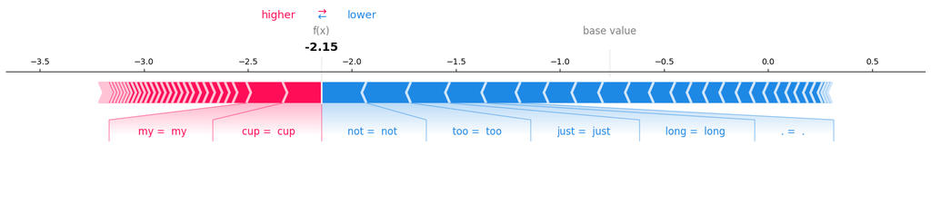

```python
shap.initjs()
shap.force_plot(shap_values[2], matplotlib = True)
```

```python
from matplotlib import pyplot as plt
```

```python
shap.text_plot(shap_values[0])
#plt.savefig('scratch_1.png')
#plt.show()
```

[figure not shown]

inputs

if

you

haven

'

t

seen

this

,

it

'

s

terrible

.

it

is

pure

trash

.

i

saw

this

about

17

years

ago

,

and

i

'

m still

screwed

up

from

it

.

- Please note that in the cell below the name of the model needs to be changed according to the name of the model that was given while saving the model by using the trainer function.

```python
# Model trained on Original Data and Tested Augmented Data
model_path = 'Models/BERT_orig_epoch2.model'
model = load_model(model_path)
explainer = shap.Explainer(lambda x: f(model, tokenizer, x), tokenizer)
shap_values = explainer(combined_test_df['combined_reviews'].iloc[[33,164, 201, 522]])
```

```
PartitionExplainer explainer: 5it [02:04, 31.17s/it]
PartitionExplainer explainer: 5it [02:04, 31.17s/it]
```

- Existence of Spurious Patterns can be observed in the text plots below.

```python
shap.text_plot(shap_values)
#plt.savefig('scratch.png')
```

[0]

[figure not shown]

inputs

who

would

imagine

ben

cartwright

as

a

das

tar

dly

cad

?

i

'

ll

leave

the

rest

of

the

star

spotting

to

you

.

[1]

[figure not shown]

inputs

it

is

an

almost

ideal

romantic

anime

!

must

see

for

all

ages

!

but

the

english

dubbed

version

is

not

too

good

.

perhaps

the

1999

version

will

be

better

.

[2]

[figure not shown]

inputs

this

movie

was

hysterical

.

i

haven

'

t

laughed

this

hard

in

a

long

time

.

amanda

pee

t

is

sick

and

bothered

.

[3]

[figure not shown]

inputs

after

catching

some

disease

in

space

,

an astronaut

comes back

to earth

and

starts

melting

.

)

this

is

the

kind

of movie

that

shouldn

'

t

have

been

made

in

the first

place

.

### Shapley Value Force Plot for the SVM Classifier

```python
def svm_explainer(pipe_arg, train_data, test_data):
    training_instance = shap.sample(train_data, 50)
    explainer_svm = shap.KernelExplainer(pipe_arg.named_steps['SVC'].predict_proba, pipe_arg.named_steps['vectorizer'].transform(training_instance))
    shap_values_svm = explainer_svm.shap_values(pipe_arg.named_steps['vectorizer'].transform([test_data]))
    feature_names = pipe_arg.named_steps['vectorizer'].get_feature_names_out()
    return explainer_svm, shap_values_svm, feature_names
```

#### Shapley Value for Trained on Original Data and Tested on Original Data

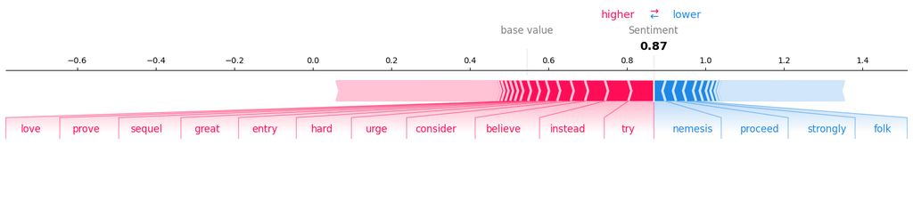

```python
explainer_svm_orig, shap_orig, feature_names_orig = svm_explainer(pipe_arg=pipe, train_data=original_train_df['Text'], test_data=original_test_df['Text'][10])
shap.initjs()
shap.force_plot(
    explainer_svm_orig.expected_value[0],
    shap_orig[0],
    feature_names=feature_names_orig,
    out_names=["Sentiment"],
    matplotlib = True,
    contribution_threshold = 0.01
)
```

#### Shapley Value for Trained on Original Data and Tested on Challenge Data

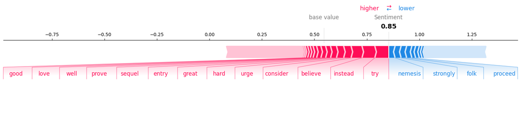

```python
explainer_svm_orig_chall, shap_orig_challenge, feature_names_orig_chall = svm_explainer(pipe_arg=pipe4, train_data=original_train_df['Text'], test_data=human_cf_test['Text'][10])
shap.initjs()
shap.force_plot(
    explainer_svm_orig_chall.expected_value[0],
    shap_orig_challenge[0],
    feature_names=feature_names_orig_chall,
    out_names=["Sentiment"],
    matplotlib = True,
    contribution_threshold = 0.01
)
```

#### Shapley Value for Trained on Original Data and Tested on Human Generated Counterfactual Data only

```python
explainer_svm_orig_cf, shap_orig_cf, feature_names_orig_cf = svm_explainer(pipe_arg=pipe9, train_data=original_train_df['Text'], test_data=cf_test['Text'][7])
```

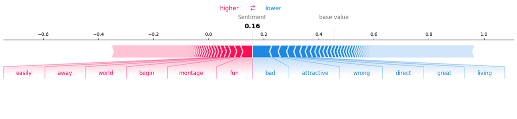

```python
#feature_names = pipe4.named_steps['vectorizer'].get_feature_names_out()
shap.initjs()
shap.force_plot(
    explainer_svm_orig_cf.expected_value[1],
    shap_orig_cf[1],
    feature_names=feature_names_orig_cf,
    out_names=["Sentiment"],
    matplotlib = True,
    show = True,
    contribution_threshold = 0.01
)
```

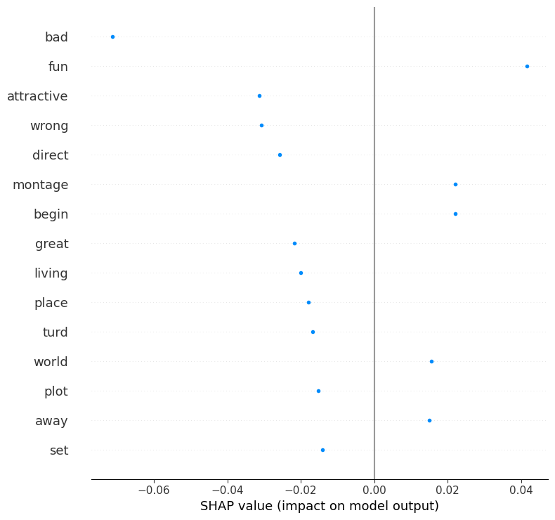

```python
shap.summary_plot(shap_orig_cf[1], feature_names = feature_names_orig_cf, max_display = 15, show_values_in_legend = True)
```

#### Trained on Challenge Data and Tested on Original Data

```python
explainer_svm_chall_orig, shap_chall_orig, feature_names_chall_orig = svm_explainer(pipe_arg=pipe6, train_data=human_cf_train['Text'], test_data=original_test_df['Text'][10])
```

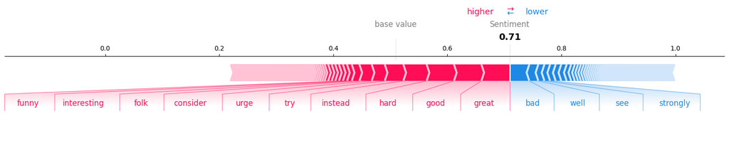

```python
shap.initjs()
shap.force_plot(
    explainer_svm_chall_orig.expected_value[0],
    shap_chall_orig[0],
    feature_names=feature_names_chall_orig,
    out_names=["Sentiment"],
    matplotlib = True,
    show = True,
    contribution_threshold = 0.01
)
```

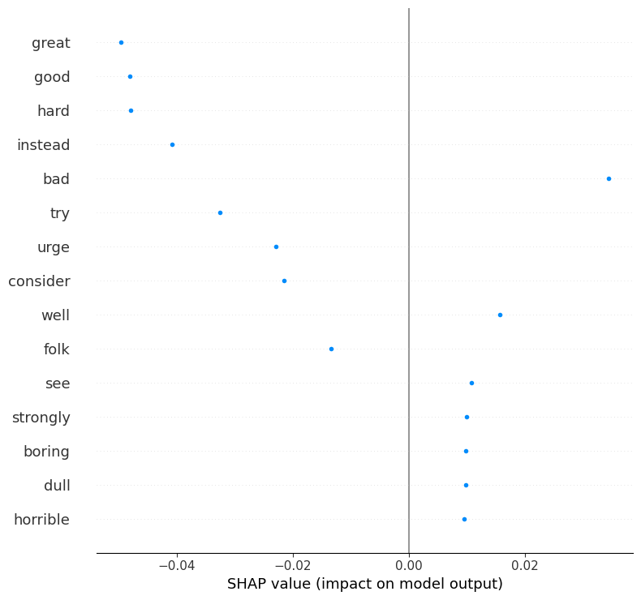

```python
shap.summary_plot(shap_chall_orig[1], feature_names = feature_names_chall_orig, max_display = 15, show_values_in_legend = True)
```